# ANOVA Examples

Michelle R. Jackson

7/25/2018

Original Date: July 11, 2018  
R version: 3.5.0 “Joy in Playing”  
Purpose: Code explains how to perform a single factor ANOVA in R Source:http://environmentalcomputing.net/analysis-variance-single-factor/

## Analysis

Download Turtles file from URL above or Github.

```r
Turtles <- read.csv(file = "Turtles.csv",header=TRUE)
```

Check that the temperature variable is a factor with the ‘str’ “string” function.

```r
str(Turtles)
```

```
## 'data.frame':    40 obs. of  2 variables:
##  $ Temperature: int  15 15 15 15 15 15 15 15 15 15 ...
##  $ Days       : int  37 43 45 54 56 65 62 73 74 75 ...
```

There are numbers for the four levels of the Temperature treatment, we need to change the variable to a factor instead of an integer.

```r
Turtles$Temperature <- factor(Turtles$Temperature)
```

We want to create an ANOVA comparing hatching time days across temperature with the ‘aov’ function.

```r
Turtles.aov <- aov(Days ~ Temperature, data = Turtles)
```

Obtain the output of the ANOVA with the ‘summary’ function.

```r
summary(Turtles.aov)
```

```
##             Df Sum Sq Mean Sq F value   Pr(>F)
## Temperature  3   8025  2675.2   15.98 9.08e-07 ***
## Residuals   36   6027   167.4
## ---
## Signif. codes:  0 '***' 0.001 '**' 0.01 '*' 0.05 '.' 0.1 ' ' 1
```

Same analysis can be created with ‘lm’ function.

```r
Turtles.lm <- lm(Days ~ Temperature,data=Turtles)
```

Obtain the output of the ‘lm’ function.

```r
summary(Turtles.lm)
```

```
##
## Call:
## lm(formula = Days ~ Temperature, data = Turtles)
##
## Residuals:
##     Min      1Q  Median      3Q     Max
## -28.200  -9.225   1.650   9.025  19.400
##
## Coefficients:
##               Estimate Std. Error t value Pr(>|t|)
## (Intercept)     58.400      4.092  14.273  < 2e-16 ***
## Temperature20  -13.800      5.787  -2.385   0.0225 *
## Temperature25   -9.200      5.787  -1.590   0.1206
## Temperature30  -38.300      5.787  -6.619 1.04e-07 ***
## ---
## Signif. codes:  0 '***' 0.001 '**' 0.01 '*' 0.05 '.' 0.1 ' ' 1
##
## Residual standard error: 12.94 on 36 degrees of freedom
## Multiple R-squared:  0.5711, Adjusted R-squared:  0.5354
## F-statistic: 15.98 on 3 and 36 DF,  p-value: 9.082e-07
```

Conduct a comparison between each mean and the other means by a Tukey test with the ‘TukeyHSD’ function.

```r
TukeyHSD(Turtles.aov)
```

```
##   Tukey multiple comparisons of means
##     95% family-wise confidence level
##
## Fit: aov(formula = Days ~ Temperature, data = Turtles)
##
## $Temperature
##        diff       lwr        upr     p adj
## 20-15 -13.8 -29.38469   1.784689 0.0982694
## 25-15  -9.2 -24.78469   6.384689 0.3969971
## 30-15 -38.3 -53.88469 -22.715311 0.0000006
## 25-20   4.6 -10.98469  20.184689 0.8562615
## 30-20 -24.5 -40.08469  -8.915311 0.0008384
## 30-25 -29.1 -44.68469 -13.515311 0.0000785
```

Look at assumptions following the code below. This line of code put two plots in the same window.

```r
par(mfrow = c(1,2))
```

Look at a histogram of the residuals.

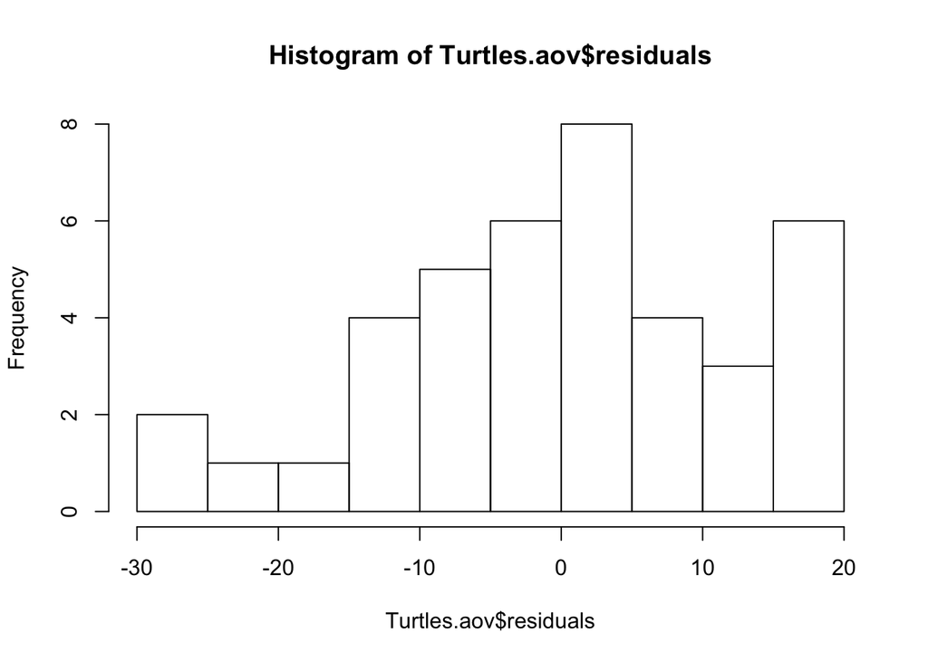

```r
hist(Turtles.aov$residuals)
```

Look at QQplot of the data.

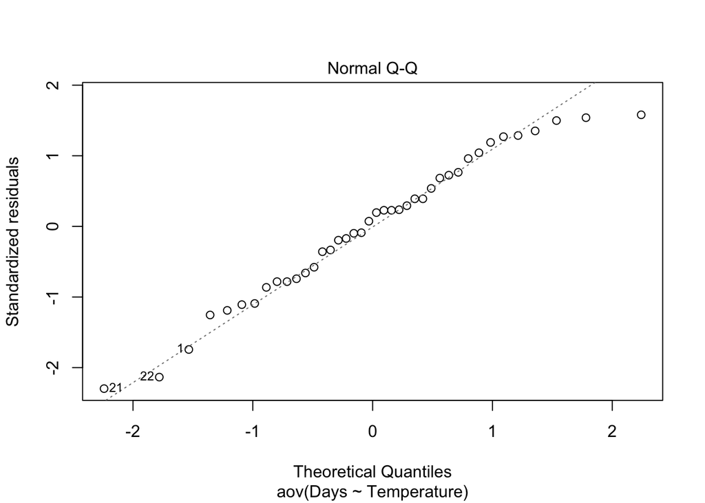

```r
plot(Turtles.aov,which=2)
```

Look at homogeneity of variance

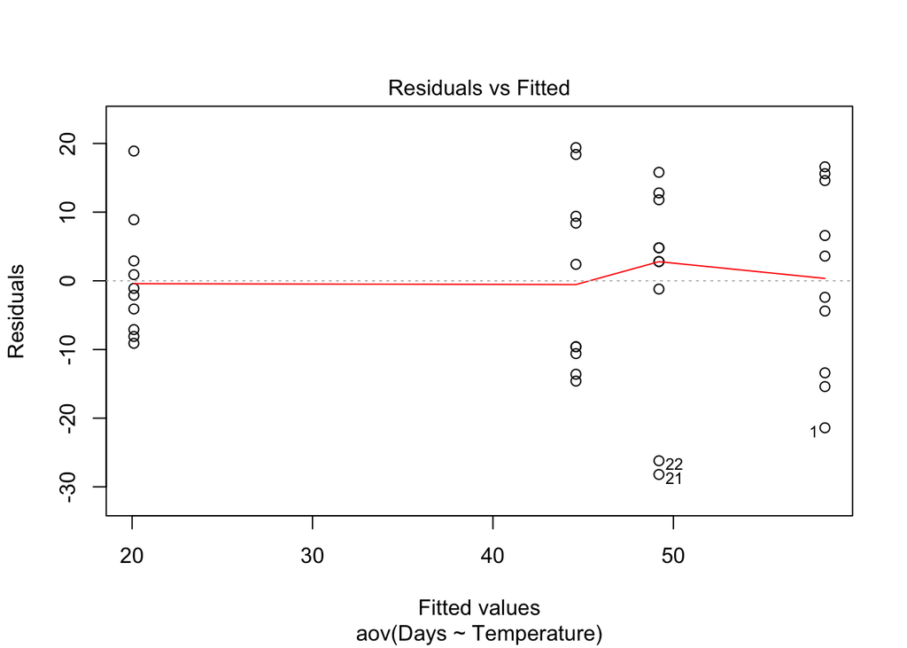

```r
plot(Turtles.aov,which=1)
```

Create a boxplot of the results.

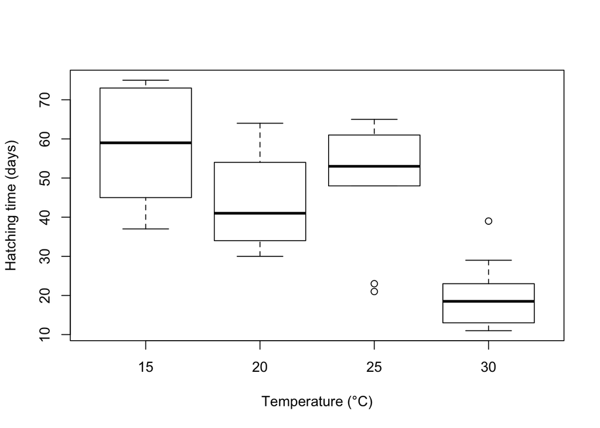

```r
boxplot(Days~Temperature, data=Turtles, ylab = "Hatching time (days)", xlab = "Temperature (°C)")
```